# Ejercicio regresión 1

Julio Sorroche García

10 de enero de 2018

#### La siguiente tabla muestra la equivalencia entre dos escalas de medición de la sensibilidad de una película:

Datos disponibles sobre película

| DIN | 12.0 | 15 | 18 | 21 | 24 | 27 | 30 | 33 | 36 |
| --- | --- | --- | --- | --- | --- | --- | --- | --- | --- |
| ASA | 12.5 | 25 | 50 | 100 | 200 | 400 | 800 | 1600 | 3200 |

##### a) Dibujar la nube de puntos

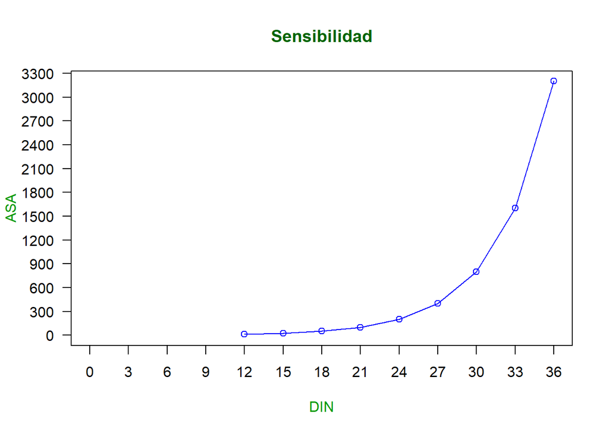

##### b) Ajustar un modelo lineal $f1(x)$ que permita aproximar la sensibilidad de una película. Evaluar $f1(25)$ ¿Qué coeficientes de $f1(x)$ son necesarios para un buen ajuste? ¿Es buen modelo? Dibujar la función obtenida junta a la nube de puntos.

**Ajuste del modelo lineal:**

```r
summary(f1x)
```

```
##
## Call:
## lm(formula = movieFrame$ASA ~ DINpre, data = movieFrame)
##
## Residuals:
##     Min      1Q  Median      3Q     Max
## -630.97 -509.72  -73.47  279.03 1205.28
##
## Coefficients:
##             Estimate Std. Error t value Pr(>|t|)
## (Intercept) -1860.28     701.87  -2.650  0.03292 *
## DINpre        107.08      27.83   3.848  0.00631 **
## ---
## Signif. codes:  0 '***' 0.001 '**' 0.01 '*' 0.05 '.' 0.1 ' ' 1
##
## Residual standard error: 646.7 on 7 degrees of freedom
## Multiple R-squared:  0.679,  Adjusted R-squared:  0.6331
## F-statistic:  14.8 on 1 and 7 DF,  p-value: 0.006312
```

Este evalua a 816.81.[^1]**

Por tanto el coeficiente necesario es **108**, siendo el modelo: $-1860 +108x$**

**Gráfica con la función obtenida del modelo lineal:**

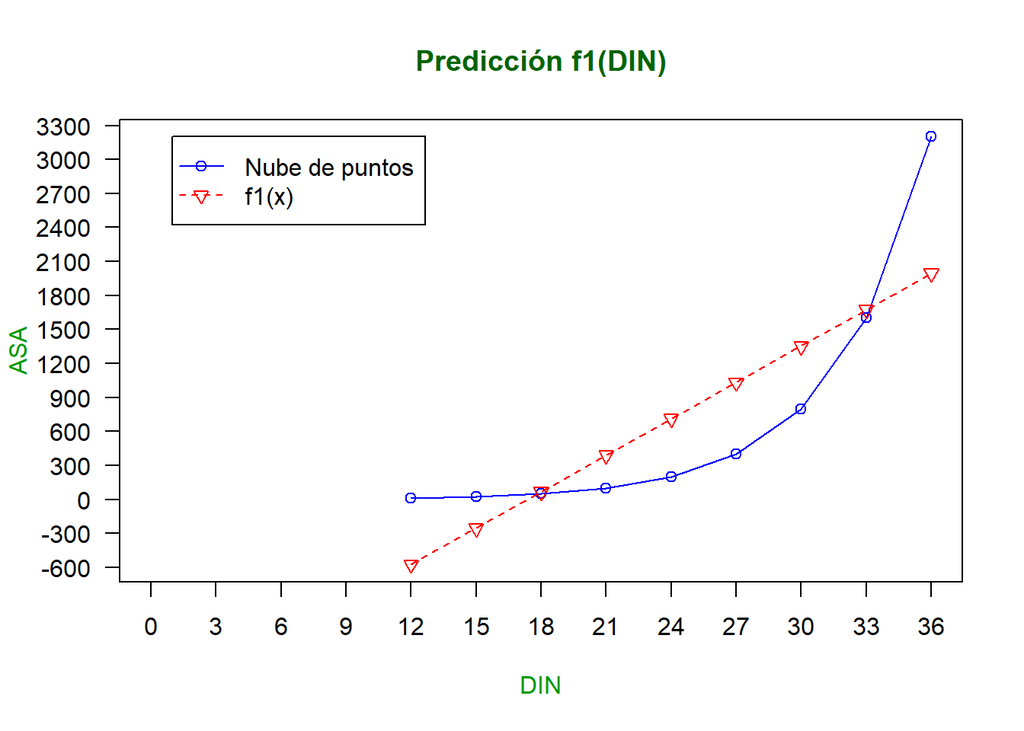

##### c) Ajustar un modelo de segundo grado $f2(x)$ que permita aproximar la sensibilidad de una película. Evaluar $f2(25)$ ¿Qué coeficientes de $f2(x)$ son necesarios para un buen ajuste? ¿Es buen modelo? Dibujar la función obtenida junta a la nube de puntos.

**Ajuste del modelo de segundo grado:**

```r
summary(f2x)
```

```
##
## Call:
## lm(formula = movieFrame$ASA ~ poly(DINpre, degree = 2), data = movieFrame)
##
## Residuals:
##     Min      1Q  Median      3Q     Max
## -315.50 -240.76   71.89  214.57  376.74
##
## Coefficients:
##                           Estimate Std. Error t value Pr(>|t|)
## (Intercept)                 709.72      96.29   7.371 0.000320 ***
## poly(DINpre, degree = 2)1  2488.39     288.87   8.614 0.000135 ***
## poly(DINpre, degree = 2)2  1557.94     288.87   5.393 0.001675 **
## ---
## Signif. codes:  0 '***' 0.001 '**' 0.01 '*' 0.05 '.' 0.1 ' ' 1
##
## Residual standard error: 288.9 on 6 degrees of freedom
## Multiple R-squared:  0.9451, Adjusted R-squared:  0.9268
## F-statistic: 51.65 on 2 and 6 DF,  p-value: 0.0001655
```

Este evalua a **234.86.**

Por tanto los coeficientes necesarios son **2489** en primer grado y **1558** en segundo, siendo el modelo: **$710+2489x +1558x^{2}$**

**Gráfica con la función obtenida del modelo polinómico de segundo grado:**

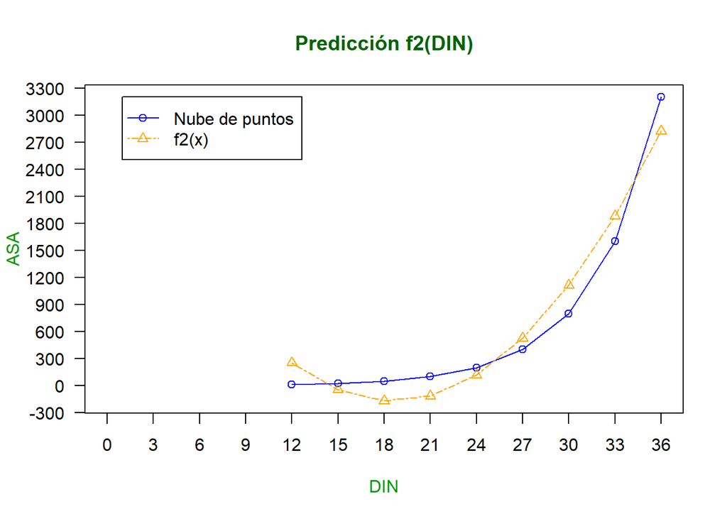

##### c) Ajustar un modelo de tercer grado $f3(x)$ que use polinomiso ortogonales. Evaluar $f3(25)$ ¿Qué coeficientes de $f3(x)$ son necesarios para un buen ajuste? ¿Es buen modelo? Dibujar la función obtenida junta a la nube de puntos.

**Ajuste del modelo de tercer grado ortogonal:**

###### La función “poly” utiliza polinomios ortogonales a menos que se le indique lo contrario

```r
summary(f3x)
```

```
##
## Call:
## lm(formula = movieFrame$ASA ~ poly(DINpre, degree = 3), data = movieFrame)
##
## Residuals:
##       1       2       3       4       5       6       7       8       9
##   58.33  -77.65  -58.23   22.29   82.09   64.34  -37.77 -131.06   77.65
##
## Coefficients:
##                           Estimate Std. Error t value Pr(>|t|)
## (Intercept)                 709.72      32.94  21.545 4.00e-06 ***
## poly(DINpre, degree = 3)1  2488.39      98.82  25.180 1.84e-06 ***
## poly(DINpre, degree = 3)2  1557.94      98.82  15.765 1.87e-05 ***
## poly(DINpre, degree = 3)3   672.19      98.82   6.802  0.00105 **
## ---
## Signif. codes:  0 '***' 0.001 '**' 0.01 '*' 0.05 '.' 0.1 ' ' 1
##
## Residual standard error: 98.82 on 5 degrees of freedom
## Multiple R-squared:  0.9946, Adjusted R-squared:  0.9914
## F-statistic: 309.6 on 3 and 5 DF,  p-value: 4.265e-06
```

Este evalua a **165.49.**

Por tanto los coeficientes necesarios son **2489** en primer grado y **1558** en segundo y **673** en tercero, siendo el modelo: **$710+2489x +1558x^{2} +673x^{3}$**

**Gráfica con la función obtenida del modelo polinómico de tercer grado:**

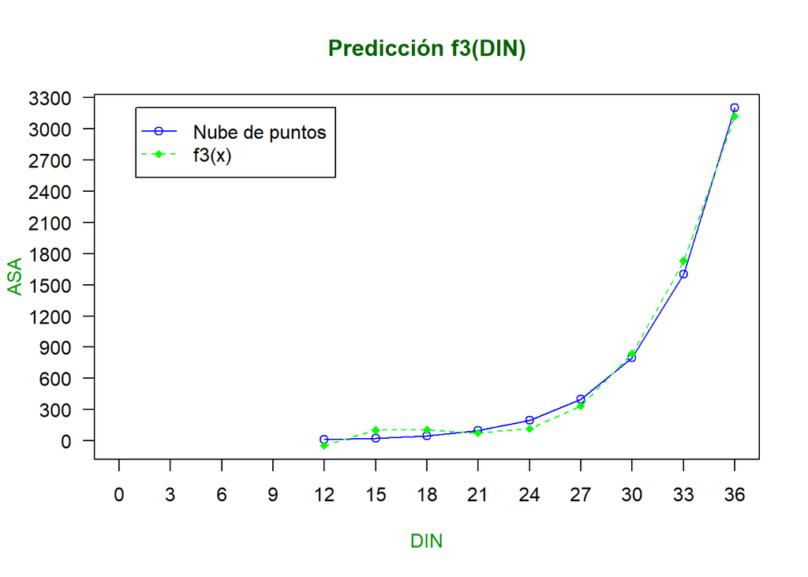

###### (e) Enfrentar los valores ajustados a los residuos de las tres funciones. Gráficamente, ¿qué función ajusta mejor?

**Valores ajustados y residuos de la función $f1(x)$:**

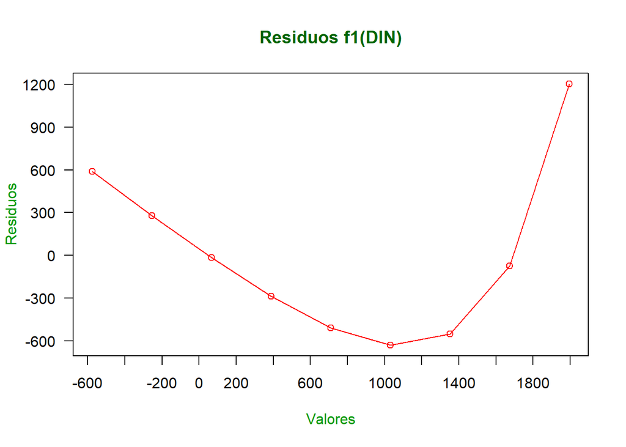

**Valores ajustados y residuos de la función $f2(x)$:**

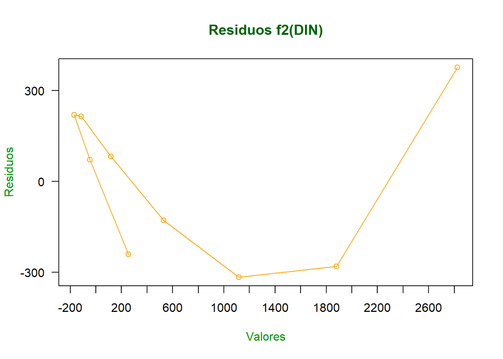

**Valores ajustados y residuos de la función $f3(x)$:**

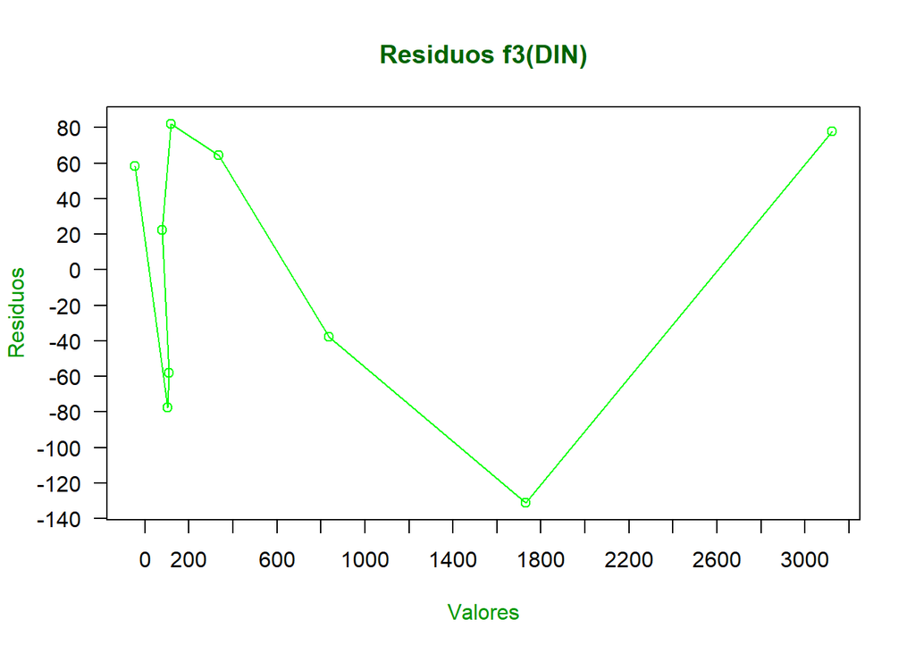

En la última gráfica podemos ver que los residuos se concentran más al comienzo, con los valores más bajos. Esto indica que $f3(x)$ es la función que mejor se ajusta. Los residuos y los valores obtenidos deben ser cuanto más similares posible.

##### (e) Comparar los modelos para ver qué modelo es el mejor (usar comando que hemos visto de R).

```r
anova(f1x,f2x,f3x)
```

```
## Analysis of Variance Table
##
## Model 1: movieFrame$ASA ~ DINpre
## Model 2: movieFrame$ASA ~ poly(DINpre, degree = 2)
## Model 3: movieFrame$ASA ~ poly(DINpre, degree = 3)
##   Res.Df     RSS Df Sum of Sq       F    Pr(>F)
## 1      7 2927837
## 2      6  500672  1   2427165 248.526 1.868e-05 ***
## 3      5   48831  1    451841  46.266  0.001046 **
## ---
## Signif. codes:  0 '***' 0.001 '**' 0.01 '*' 0.05 '.' 0.1 ' ' 1
```

[^1]: Mientras que los resúmenes poseen los datos exactos, las evaluaciones han sido limitadas a dos decimales y los coeficientes han sido redondeados superiormente.